# Data Visualization I

## Color, size, shape and other aesthetic attributes

The aesthetic mappings take properties of the data and use them to influence visual characteristics, such as position, color, size, shape, or transparency. Each visual characteristic can encode an aspect of the data and be used to convey information.

All aesthetics for a plot are specified in the `aes()` function call. For example, we can add a mapping from variable denoting CA observations to the color characteristic:

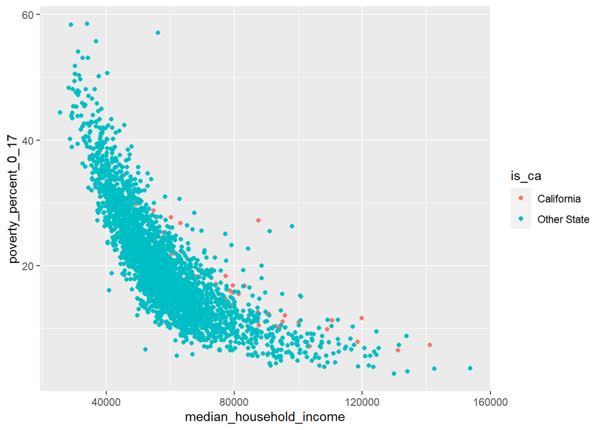

```r
# Canvas + variables mapped to axes + shapes + color
ggplot(data = all_counties,
       aes(x = median_household_income,
           y = poverty_percent_0_17,
           color = is_ca)) +
  geom_point()
```

Note that using the `aes()` function will cause the visual channel to be based on the data specified in the argument. For example, using `aes(color = "blue")` won’t cause the geometry’s color to be “blue”, but will instead cause the visual channel to be mapped from the vector `c("blue")`.

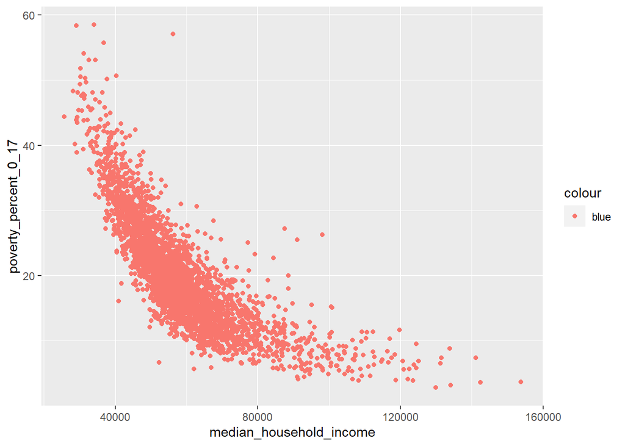

```r
ggplot(data = all_counties,
       aes(x = median_household_income,
           y = poverty_percent_0_17,
           color = "blue")) +
  geom_point()
```

If you wish to apply an aesthetic property to an entire geometry, you can set that property as an argument to the `geom` method, outside of the `aes()` call:

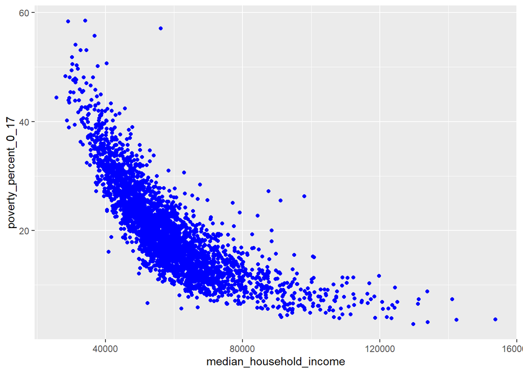

```r
ggplot(data = all_counties,
       aes(x = median_household_income,
           y = poverty_percent_0_17)) +
  geom_point(color = "blue")
```

You can use the alpha argument within the `geom_point()` function in ggplot2 to modify the transparency of the points in a plot. The value for alpha can range between 0 and 1 where: 0 is completely transparent. 1 is completely solid.

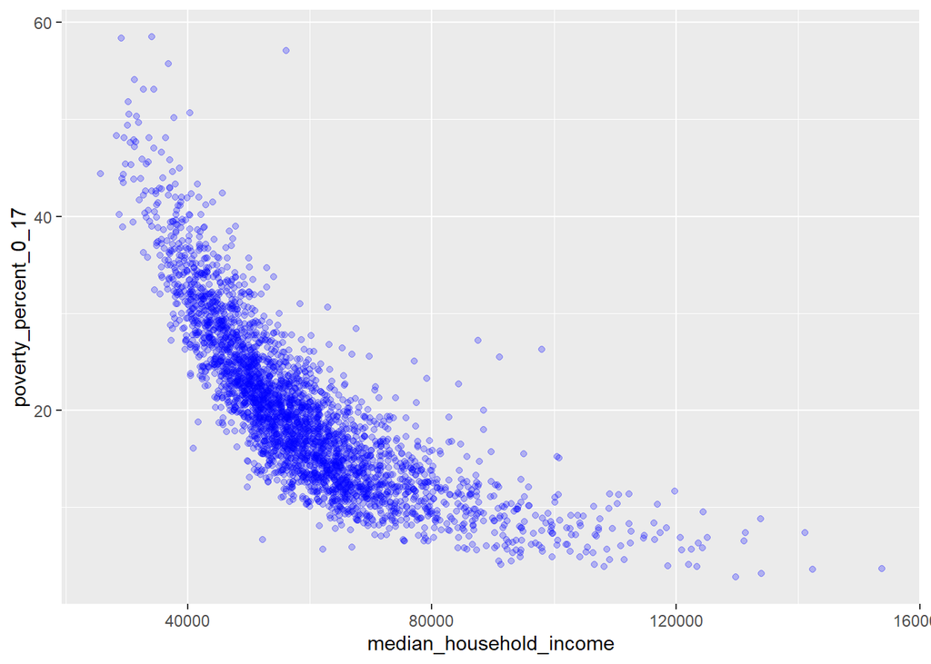

```r
ggplot(data = all_counties,
       aes(x = median_household_income,
           y = poverty_percent_0_17)) +
  geom_point(color = "blue", alpha = 0.25) #change it
```

## Specifying Geometric Shapes

Building on these basics, **{ggplot2}** can be used to build almost any kind of plot you may want. These plots are declared using functions that follow from the Grammar of Graphics.

You might guess that by substituting `geom_point()` for a different geom function, you’d get a different type of plot. That’s a great guess!

Let’s check out some geoms:

### geom_smooth()

This function fits a smoother to the data and displays the smooth and its standard error. For example, replace the `geom_points()` for `geom_smoot()`:

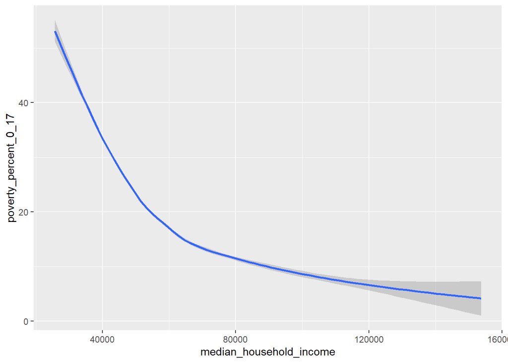

```r
ggplot(data = all_counties,
       aes(x = median_household_income,
           y = poverty_percent_0_17)) +
  geom_smooth()
```

Because the aesthetic mapping is the same that we used with our points, we can actually use them together:

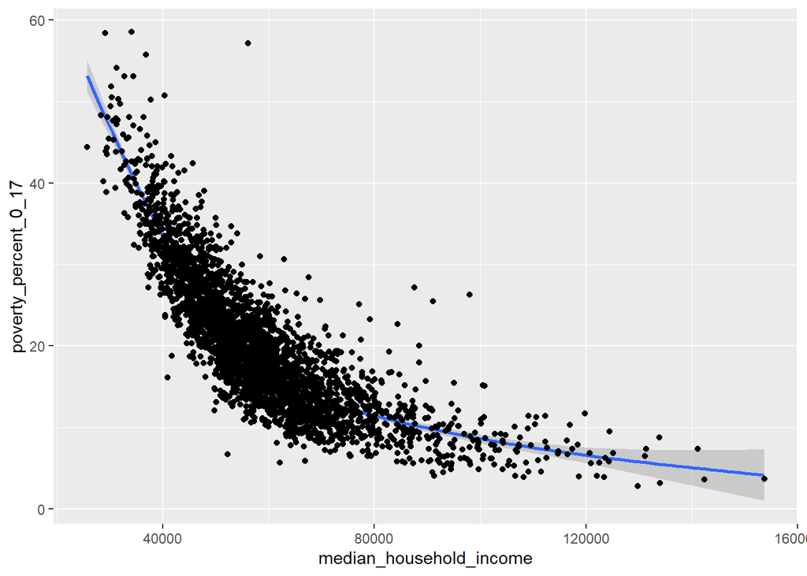

```r
ggplot(data = all_counties,
       aes(x = median_household_income,
           y = poverty_percent_0_17)) +
  geom_smooth() +
  geom_point()
```

Notice that the order of the layers matters, here the points are above the smooth line, which makes it hard to read. Change that:

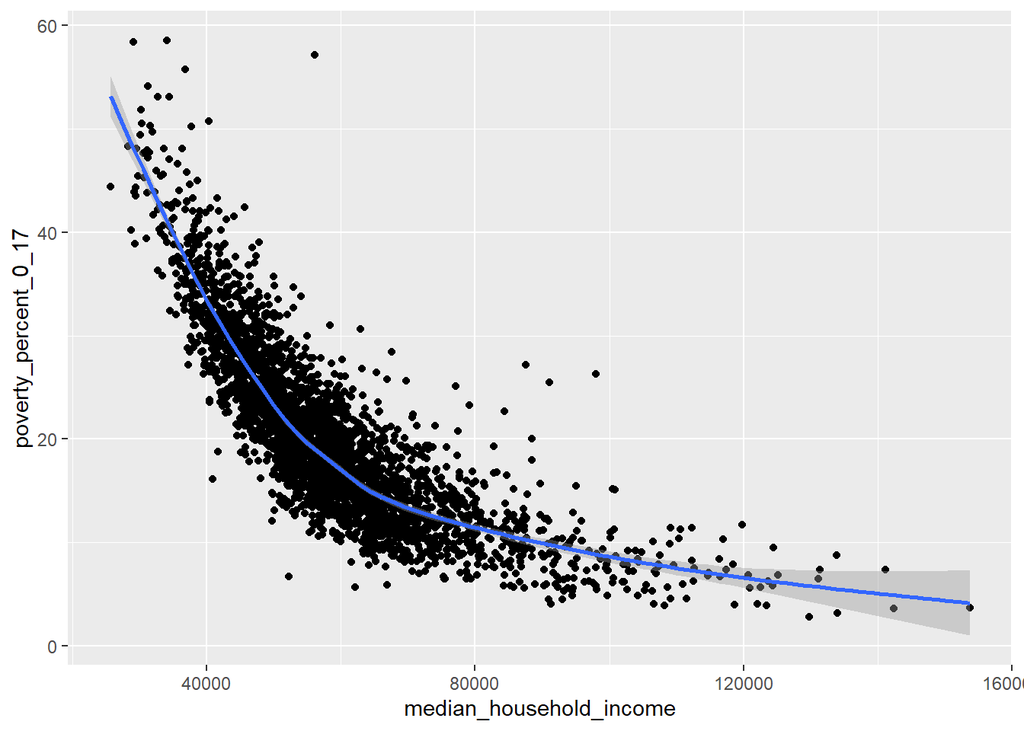

```r
ggplot(data = all_counties,
       aes(x = median_household_income,
           y = poverty_percent_0_17)) +
  geom_point() +
  geom_smooth()
```

Much better, but we can clean up the graph a bit adding arguments to the geoms:

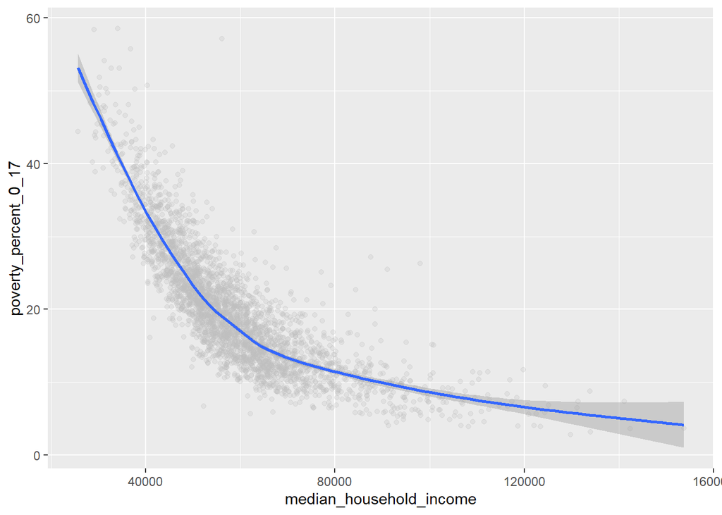

```r
ggplot(data = all_counties,
       aes(x = median_household_income,
           y = poverty_percent_0_17)) +
  geom_point(alpha = 0.25, color = "grey") +
  geom_smooth()
```

Much better!

### geom_boxplot() and geom_violin()

Produces a box-and-whisker plot to summarise the distribution of a set of points. To make sense of this function let’s take a quick step back. When a set of data includes a categorical variable and one or more continuous variables, you will probably be interested to know how the values of the continuous variables vary with the levels of the categorical variable.

Say which states have higher percents of poverty for populations 0-17. We might start with a scatterplot like this:

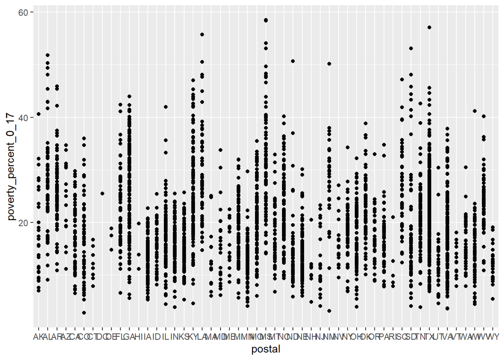

```r
ggplot(data = all_counties,
       aes(x = postal,
           y = poverty_percent_0_17)) +
  geom_point()
```

This is hard to see, so let’s only focus on west coast states to demonstrate a point. To do so, let’s filter down our data a bit more:

```r
best_coast_counties <- all_counties %>%
  # The %in% operator in R is used to check if a value is present in a vector or a list of values
  filter(postal %in% c("CA", "OR", "WA"))
```

Now try the prior visualization once again:

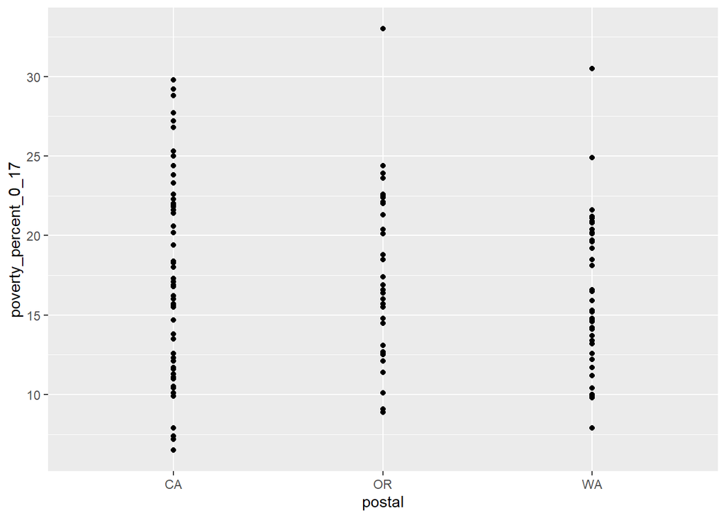

```r
ggplot(data = best_coast_counties,
       aes(x = postal,
           y = poverty_percent_0_17)) +
  geom_point()
```

First, let look at boxplots using the `geom_boxplot()` function, which summarise the shape of the distribution with a handful of summary statistics.

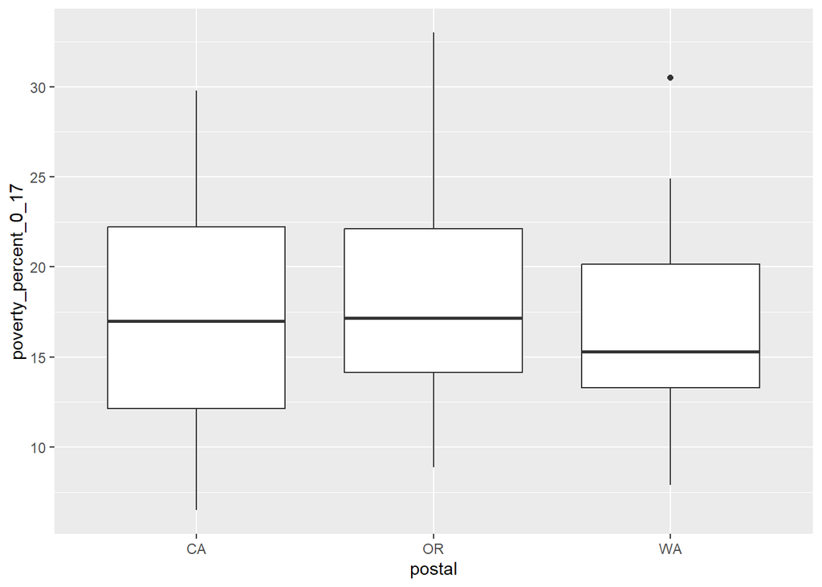

```r
ggplot(data = best_coast_counties,
       aes(x = postal,
           y = poverty_percent_0_17)) +
  geom_boxplot()
```

So what are we looking at? The function visualizes five summary statistics (the median, two hinges and two whiskers), and all “outlying” points individually. The hinges help us see the spread and skewness of the numerical data. The whiskers extend that extend past the box indicate the variability outside the upper and lower quartiles.

Another approach to visualizing the distribution for categorical data is using the `geom_violin()` function:

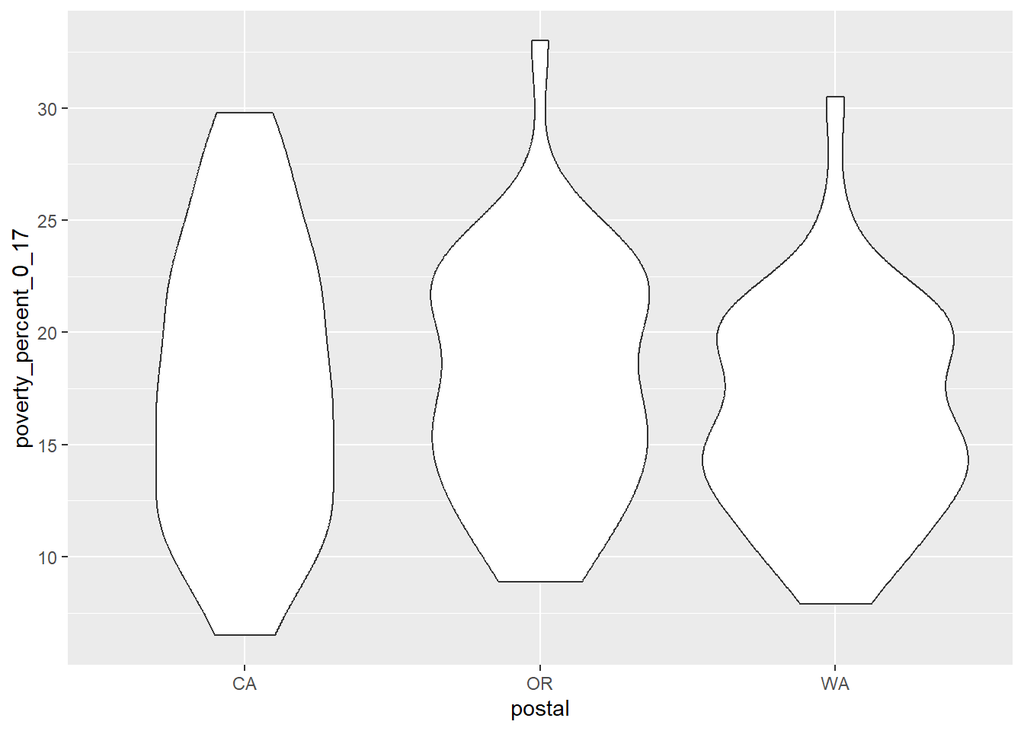

```r
ggplot(data = best_coast_counties,
       aes(x = postal,
           y = poverty_percent_0_17)) +
  geom_violin()
```

This function shows a compact representation of the “density” of the distribution, highlighting areas where more points are found.

Each method has its strengths and weaknesses. Boxplots summarise the bulk of the distribution with only five numbers, while jittered plots show every point but only work with relatively small datasets. Violin plots give the richest display, but rely on the calculation of a density estimate, which can be hard to interpret.

### Histograms and frequency polygons

Histograms and frequency polygons show the distribution of a single numeric variable. They provide more information about the distribution of a single group than boxplots do, at the expense of needing more space.

Take a look at a histogram:

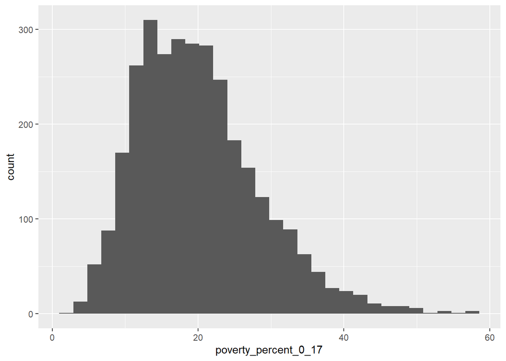

```r
ggplot(data = all_counties,
       aes(poverty_percent_0_17))  +
  geom_histogram()
```

Take a look at a frequency polygon:

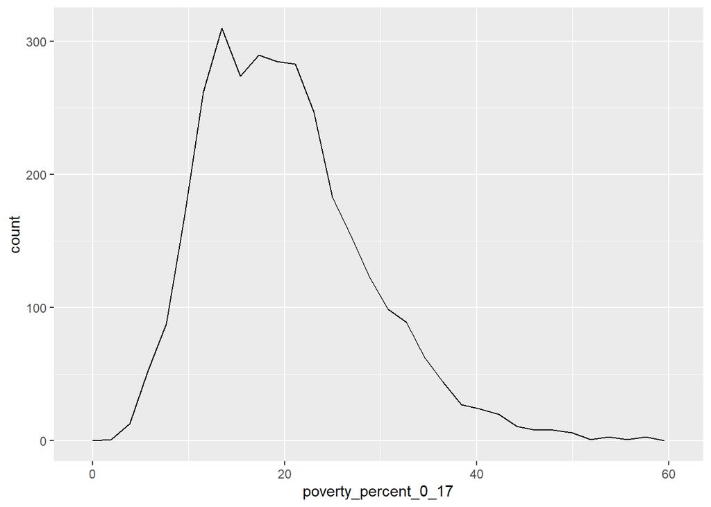

```r
ggplot(data = all_counties,
       aes(poverty_percent_0_17))  +
  geom_freqpoly()
```

Both histograms and frequency polygons work in the same way: they bin the data, then count the number of observations in each bin. The only difference is the display: histograms use bars and frequency polygons use lines.

You can control the width of the bins with the `binwidth` argument . It is very important to experiment with the bin width. The default just splits your data into 30 bins, which is unlikely to be the best choice. You should always try many bin widths, and you may find you need multiple bin widths to tell the full story of your data.

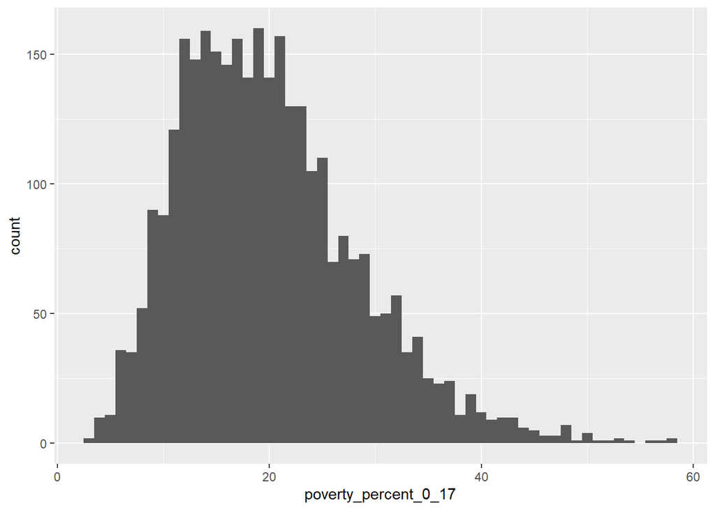

```r
ggplot(data = all_counties,
       aes(poverty_percent_0_17))  +
  geom_histogram(binwidth = 1) #each bin covers a percent increase
```

### Bar Charts

The discrete analogue of the histogram is the bar chart, `geom_bar()`. It’s easy to use:

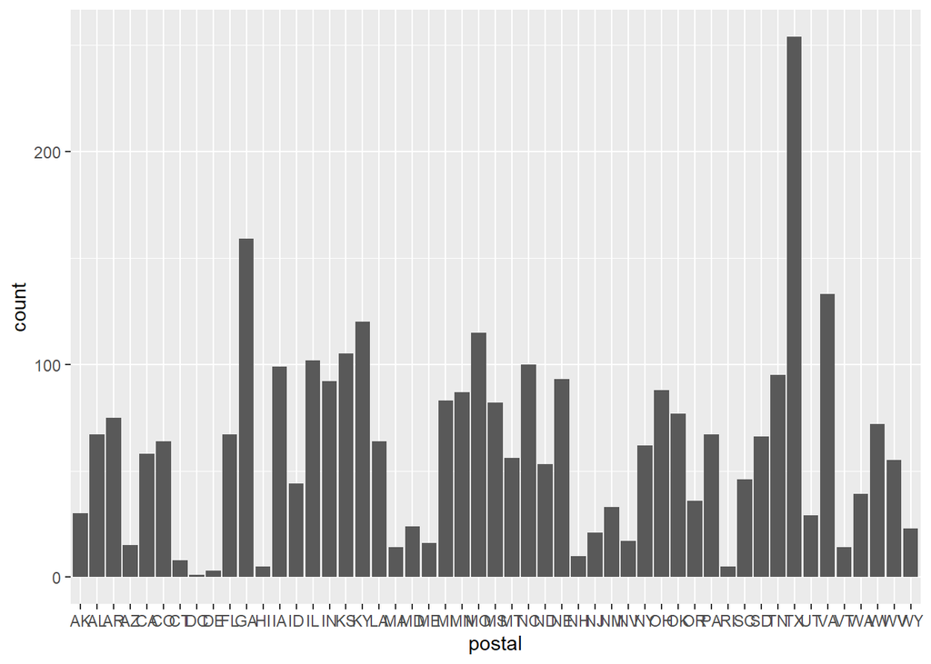

```r
ggplot(data = all_counties,
       aes(postal))  +
  geom_bar()
```

Again, a bit crowded, lets use the smaller west coast data:

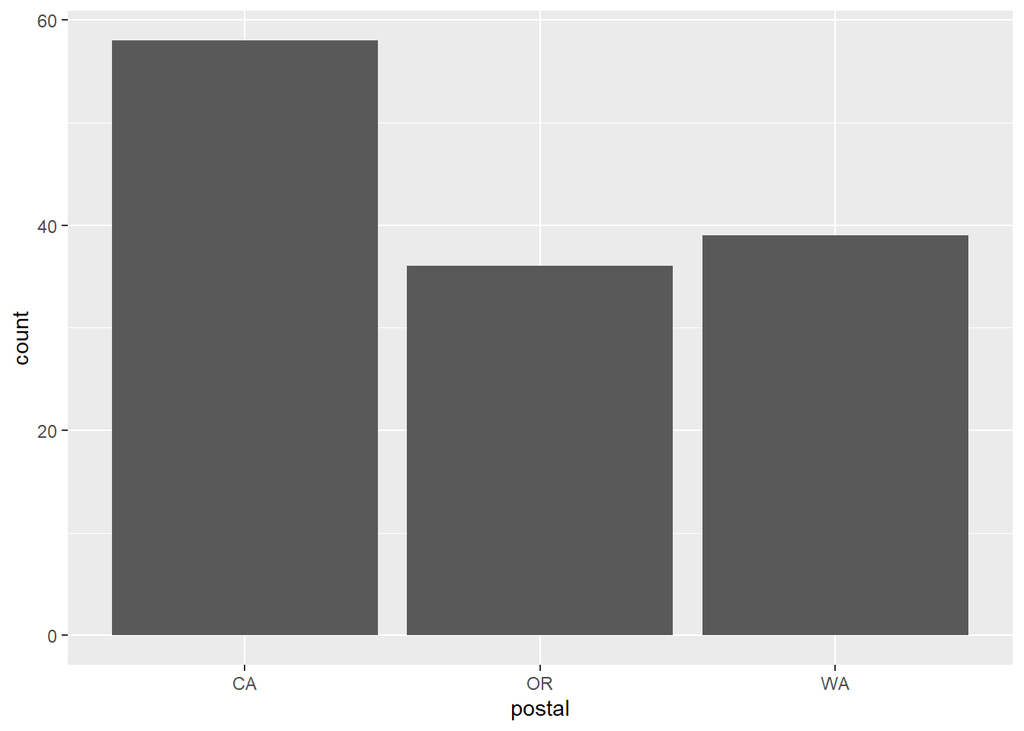

```r
ggplot(data = best_coast_counties,
       aes(postal))  +
  geom_bar()
```

Bar charts can be confusing because there are two rather different plots that are both commonly called bar charts. The above form expects you to have unsummarised data, and each observation contributes one unit to the height of each bar. So the height is the number of counties in each state.

The other form of bar chart is used for presummarised data. For example:

```r
drugs <- data.frame(
  drug = c("a", "b", "c"),
  effect = c(4.2, 9.7, 6.1)
)
```

To display this sort of data, you need to tell `geom_bar()` to not run the default stat which bins and counts the data.

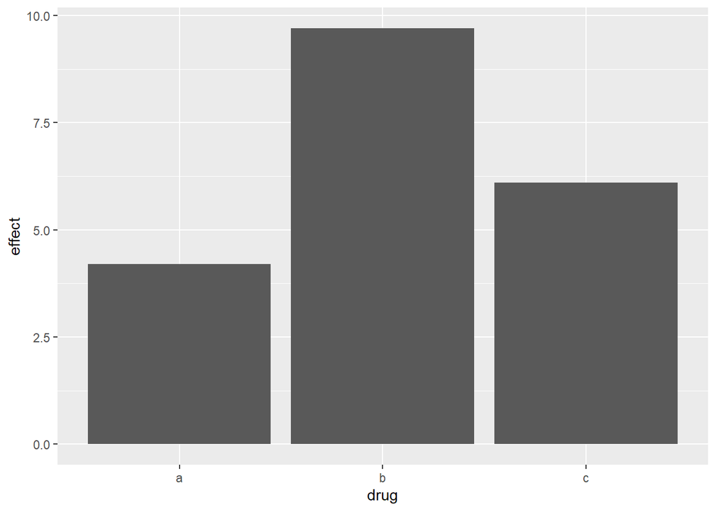

```r
ggplot(drugs, aes(drug, effect)) +
  geom_bar(stat = "identity")
```

In this example, the height is the effect value, not the number of observations.

## Labels & Annotations

Textual labels and annotations (on the plot, axes, geometry, and legend) are an important part of making a plot understandable and communicating information. **{ggplot}** makes it very easy to add such annotations.